# pml_Course_Project

```r
setwd("~/Google Drive/Coursera/PracticalMachineLearning/Project")
library(parallel)
library(doParallel)
library(caret)
library(randomForest)
cluster <- makeCluster(detectCores() - 1)
registerDoParallel(cluster)
training <- read.csv("pml-training.csv")
testing <- read.csv("pml-testing.csv")
```

Subset the two datasets, removing any variables with any NaN or inifinite entries.

```r
badTr <- apply(training, 2, function(x) any(is.na(x) | is.infinite(x)))
badTe <- apply(testing, 2, function(x) any(is.na(x) | is.infinite(x)))
trainSet <- training[!badTr]
testSet <- testing[!badTe]
```

By looking at the data, it appears as if all variables of type factor do not add anything meaningful to our upcoming model construction. These factors are, for example, names of participants and error terms on the measured quantities.

```r
y <- trainSet[,93]
isFac <- sapply(trainSet, function(x) is.factor(x))
trainSet <- trainSet[!isFac]
x <- trainSet[,c(-1,-2,-3)]
xTest <- testSet[names(testSet) %in% names(x)]
```

## Set the training features

Here we tell our model that we will use cross-validation three times, while allowing parallel computations to save time. Normally, cross-validation is performed closer to 10 times, but with the number of variables we have to build our model on, it should not take that many to get good accuracy. (Indeed this is the case, as the model results below show).

```r
fitControl <- trainControl(method = "cv", number = 3, allowParallel = TRUE)
```

## Train the Model

We will use the random forest method on x and y as calculated above. This is one of the best methods when doing classifications, as we are here. Set the tuning parameter mtry to 7 to save time.

```r
fit <- train(x, y, method="rf", trControl=fitControl, tuneGrid=data.frame(mtry=7))
fit
```

```
## Random Forest
##
## 19622 samples
##    53 predictor
##     5 classes: 'A', 'B', 'C', 'D', 'E'
##
## No pre-processing
## Resampling: Cross-Validated (3 fold)
## Summary of sample sizes: 13081, 13082, 13081
## Resampling results:
##
##   Accuracy  Kappa
##   0.997248  0.996519
##
## Tuning parameter 'mtry' was held constant at a value of 7
```

```r
fit$resample
```

```
##    Accuracy     Kappa Resample
## 1 0.9975539 0.9969061    Fold1
## 2 0.9969419 0.9961318    Fold2
## 3 0.9972481 0.9965192    Fold3
```

```r
confusionMatrix.train(fit)
```

```
## Cross-Validated (3 fold) Confusion Matrix
##
## (entries are percentual average cell counts across resamples)
##
##           Reference
## Prediction    A    B    C    D    E
##          A 28.4  0.0  0.0  0.0  0.0
##          B  0.0 19.3  0.1  0.0  0.0
##          C  0.0  0.0 17.4  0.1  0.0
##          D  0.0  0.0  0.0 16.3  0.0
##          E  0.0  0.0  0.0  0.0 18.3
##
##  Accuracy (average) : 0.9972
```

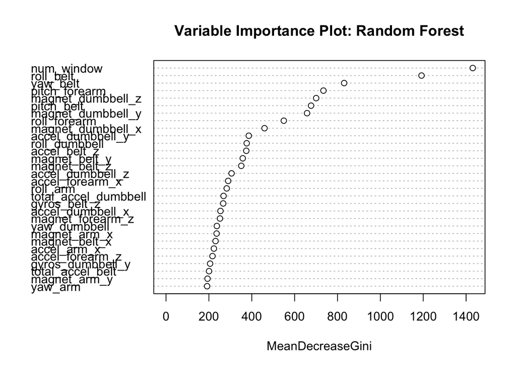

```r
varImpPlot(fit$finalModel, main="Variable Importance Plot: Random Forest")
```

```r
stopCluster(cluster)
registerDoSEQ()
```

## Get out-of-sample error

```r
fit$finalModel
```

```
##
## Call:
##  randomForest(x = x, y = y, mtry = param$mtry)
##                Type of random forest: classification
##                      Number of trees: 500
## No. of variables tried at each split: 7
##
##         OOB estimate of  error rate: 0.13%
## Confusion matrix:
##      A    B    C    D    E  class.error
## A 5579    1    0    0    0 0.0001792115
## B    2 3794    1    0    0 0.0007900974
## C    0    4 3418    0    0 0.0011689071
## D    0    0   11 3204    1 0.0037313433
## E    0    0    0    5 3602 0.0013861935
```

The out-of-sample (OOB) error rate is shown above.

## Make predictions on the test dataset

```r
predTest <- predict(fit, xTest)
```

The test predictions are B, A, B, A, A, E, D, B, A, A, B, C, B, A, E, E, A, B, B, B.